# Final Project R Reference

Juliana Berube

12/2/2021

# R Reference Guide

## Loading Data and Packages

To use load data using “require” and “here”

```r
require(here)
library (palmerpenguins)

#To load the ginkgo data:

ginkgo = read.csv(here("data", "ginkgo_data_2021.csv"))
```

## Data Structures

### c( )

The function c( ) combines or concatenates its arguments into a vector (a 1-dimensional data structure consisting of 1 or more elements).

- All of the elements must be of the same type.
- I can’t combine character and numeric types in the same call to c( )

Here’s two examples using numeric and character data types:

```r
## Create a vector of numbers:
num_vec  = c(1, 4, 8, 9, 13)

## Create a vector of characters:
char_vec = c("a", "fish", "data is cool")
```

I can show the contents of a vector by typing the name of the vector, or using the print() function.

```r
## Typing the name of the vector into the console prints the contents
num_vec
```

```
## [1]  1  4  8  9 13
```

```r
## The print() function accomplishes the same task:
print(char_vec)
```

```
## [1] "a"            "fish"         "data is cool"
```

### length( )

“Get or set the length of vectors (including lists) and factors, and of any other R object for which a method has been defined” - R Help

Arguments can either be x (R object) or a value (interger)

```r
length(num_vec)
```

```
## [1] 5
```

In a data frame, the length argument is restricted to the number of columns:

```r
length(ginkgo)
```

```
## [1] 6
```

Can also be used inside loops and other functions to find the length or number of repetitions (come back to this)

### Matrix ( )

An array (2 dimensional) of numbers or characters arranged into rows and columns.

Formula:

matrix(data = NA, nrow = 1, ncol = 1, byrow = FALSE, dimnames = NULL)

```r
matrix(1:9, nrow = 3, ncol = 3)
```

```
##      [,1] [,2] [,3]
## [1,]    1    4    7
## [2,]    2    5    8
## [3,]    3    6    9
```

The automatic arrangment is columns, then row.

You can also turn vectors into matrixes. Here is an example of creating multiple matrixes with different lengths from one vector.

```r
my_vec<-c(1,2,3)
mat_1 = matrix(my_vec)
mat_1[3,1]
```

```
## [1] 3
```

```r
vec_2<-c("one", "two", "three")
vec_3<-c(1.0, 2.0, 3.0)

mat_2=matrix(my_vec, nrow=2, ncol = 3)
mat_3=matrix(my_vec, nrow=3, ncol = 2)
mat_4=matrix(my_vec, nrow=5, ncol=5)
```

You can use length() here too to get the length of a matrix

```r
length(mat_2)
```

```
## [1] 6
```

### data.frame ( )

This function will create a data frame. Data frames store data tables and can contain multiple types of data in field (whereas a matrix has all the same type of data). Each column contains one variable, and each row contains one set of values from each column. A data frame can be created like this:

```r
ex_month.data <- data.frame(
   month = c (1:12),
   month_name = c("Jan","Feb","Mar","Apr","May", "Jun", "July", "Aug", "Sep", "Oct", "Nov", "Dec"),
   sunny_days = c(20,15,19,10,22,25, 28, 21, 17, 16, 18, 14))
```

### nrow( ), ncol( ), dim( )

You can also find the number of rows and columns in a data frame like this:

```r
nrow(ginkgo)
```

```
## [1] 756
```

```r
ncol(ginkgo)
```

```
## [1] 6
```

```r
dim(ginkgo)
```

```
## [1] 756   6
```

## Subsetting

Lets go through some subsets using our ginkgo data. Some ways to do this is to use $ to subset by column name, [] to subset by name, position, row, or column, and subset()

```r
ginkgo$max_depth
```

```
##   [1]  40  38  32  40  40  50  42  35  45  37  41  42  50  46  46  46  42  43
##  [19]  44  37  46  45  51  40  36  37  40  57  58  46  53  64  45  64  56  55
##  [37]  55  60  40  43  59  55  49  60  45  58  53  38  56  68  53  55  59  54
##  [55]  52  39  59  60  51  62  41  53  50  33  31  51  58  51  57  57  49  45
##  [73]  49  39  40  49  47  49  55  46  40  38  32  40  40  50  42  35  45  37
##  [91]  41  42  50  46  46  46  42  43  44  37  46  45  51  40  36  37  40  55
## [109]  46  37  43  50  56  58  48  55  46  45  54  67  41  45  55  54  40  45
## [127]  36  48  55  55  54  34  50  42  49  55 105 109 145 111  95  91  94  85
## [145] 138 121 110 127 108 100  96  97  97 104  93  87  69 102  70  97  98 103
## [163]  95  94  96 104 107  75 105  82  89 106 115  87  55  41  49  57  41  45
## [181]  56  60  53  41  40  42  47  51  51  43  49  58  56  41  68  50  55  44
## [199]  38  39  32 104  71 120 109  90  93  66  72  84  80 103  80  65  85  90
## [217]  62  92  71  89  95  80  55  55  38  23  41  40  47  58  87 100  91 111
## [235] 106 106 100 113  98 103  93  79  85  95  62 103  80  78  89  84 108  79
## [253] 111 106 100  67 105 108  81 127 110  88  97  85  85 106  92 113 125  70
```

[output cut: 27 more lines]

```r
#you can assign this to a seperate data frame by naming it: depth=ginkgo$max_depth
#[] subsetting chooses by row, column
#select first row of the ginkgo data:
ginkgo[1,]
```

```
##   site_id seeds_present max_width max_depth notch_depth petiole_length
## 1    7719         FALSE        71        40           0             30
```

```r
#select the element in row 2, column 3:
ginkgo[2,3]
```

```
## [1] 64
```

```r
#select the 3rd column of the ginkgo data
ginkgo[,3]
```

```
##   [1]  71.0  64.0  55.0  62.0  65.0  70.0  63.0  56.0  51.0  57.0  59.0  63.0
##  [13]  70.0  50.0  56.0  46.0  54.0  62.0  56.0  55.0  59.0  60.0  63.0  61.0
##  [25]  58.0  55.0  53.0  81.0  94.0  75.0  82.0  86.0  79.0  93.0  88.0  76.0
##  [37]  71.0  91.0  71.0  82.0  65.0  83.0  73.0 102.0  78.0  88.0  81.0  70.0
##  [49]  80.0  96.0  80.0  82.0  86.0  87.0  89.0  69.0  93.0  98.0  81.0  79.0
##  [61]  82.0  85.0  81.0  59.0  53.0  83.0  80.0  77.0  81.0  76.0  82.0  81.0
##  [73]  77.0  68.0  41.0  70.0  68.0  80.0  89.0  90.0  71.0  64.0  55.0  62.0
##  [85]  65.0  70.0  63.0  56.0  51.0  57.0  59.0  63.0  70.0  50.0  56.0  46.0
##  [97]  54.0  62.0  56.0  55.0  59.0  60.0  63.0  61.0  58.0  55.0  53.0  77.0
## [109]  72.0  57.0  75.0  75.0  75.0  67.0  74.0  71.0  72.0  55.0  77.0  97.0
## [121]  73.0  64.0  69.0  92.0  64.0  68.0  53.0  97.0 100.0  90.0  89.0  59.0
## [133]  97.0  76.0  85.0  90.0  87.0  85.0  80.0  86.0  89.0  84.0  88.0  80.0
## [145] 102.0  94.0  95.0 109.0  84.0  68.0  59.0  74.0  70.0  71.0  69.0  74.0
## [157]  70.0  78.0  87.0  69.0  60.0  72.0  59.0  75.0  81.0  82.0  74.0  72.0
## [169]  79.0  84.0  75.0  72.0  88.0  80.0  90.0  58.0  61.0  95.0  72.0  90.0
```

[output cut: 48 more lines]

```r
#retrieve all the data for Adelie penguins (in the species column) from the penguins dataset
subset(penguins, species == "Adelie")
```

```
## # A tibble: 152 × 8
##    species island    bill_length_mm bill_depth_mm flipper_length_mm body_mass_g
##    <fct>   <fct>              <dbl>         <dbl>             <int>       <int>
##  1 Adelie  Torgersen           39.1          18.7               181        3750
##  2 Adelie  Torgersen           39.5          17.4               186        3800
##  3 Adelie  Torgersen           40.3          18                 195        3250
##  4 Adelie  Torgersen           NA            NA                  NA          NA
##  5 Adelie  Torgersen           36.7          19.3               193        3450
##  6 Adelie  Torgersen           39.3          20.6               190        3650
##  7 Adelie  Torgersen           38.9          17.8               181        3625
##  8 Adelie  Torgersen           39.2          19.6               195        4675
##  9 Adelie  Torgersen           34.1          18.1               193        3475
## 10 Adelie  Torgersen           42            20.2               190        4250
## # … with 142 more rows, and 2 more variables: sex <fct>, year <int>
```

## Numerical Data Exploration

To view our data we can use functions like summary(), mean(), and sd()

```r
#Summary of the entire dataset
summary(ginkgo)
```

```
##     site_id      seeds_present     max_width        max_depth
##  Min.   : 1896   Mode :logical   Min.   : 16.00   Min.   : 19.00
##  1st Qu.: 3703   FALSE:636       1st Qu.: 63.00   1st Qu.: 43.00
##  Median : 6066   TRUE :120       Median : 74.00   Median : 51.00
##  Mean   : 6079                   Mean   : 74.34   Mean   : 58.51
##  3rd Qu.: 7206                   3rd Qu.: 85.00   3rd Qu.: 66.00
##  Max.   :12982                   Max.   :130.00   Max.   :145.00
##
##   notch_depth    petiole_length
##  Min.   : 0.00   Min.   :  8.00
##  1st Qu.: 0.00   1st Qu.: 34.00
##  Median : 0.00   Median : 47.00
##  Mean   : 2.99   Mean   : 48.25
##  3rd Qu.: 4.00   3rd Qu.: 60.00
##  Max.   :49.00   Max.   :113.00
##                  NA's   :4
```

```r
#Summary of a column
summary(ginkgo$max_width)
```

```
##    Min. 1st Qu.  Median    Mean 3rd Qu.    Max.
##   16.00   63.00   74.00   74.34   85.00  130.00
```

```r
#mean of a column
mean(ginkgo$max_width)
```

```
## [1] 74.33823
```

```r
#sd of a column
sd(ginkgo$max_width)
```

```
## [1] 16.4203
```

## Graphical Data Exploration

To represent data my favorite way: graphically.

### Scatterplots

Lets begin with a scatterplot…

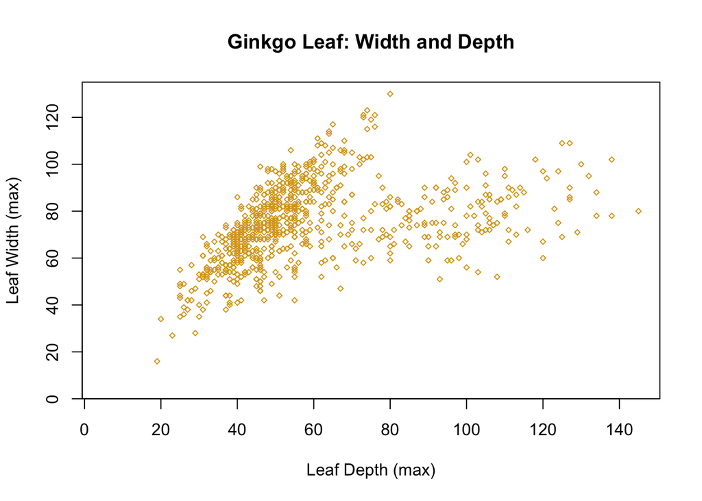

```r
plot(max_width~max_depth, data = ginkgo,
     xlim=c(5,145),
     ylim=c(5, 130),
     xlab= "Leaf Depth (max)",
     ylab= "Leaf Width (max)",
     main= "Ginkgo Leaf: Width and Depth",
     col= "goldenrod",
     cex= 0.5,
     pch=5)
```

So pretty!

### Histogram

Let’s do a histogram of penguin data:

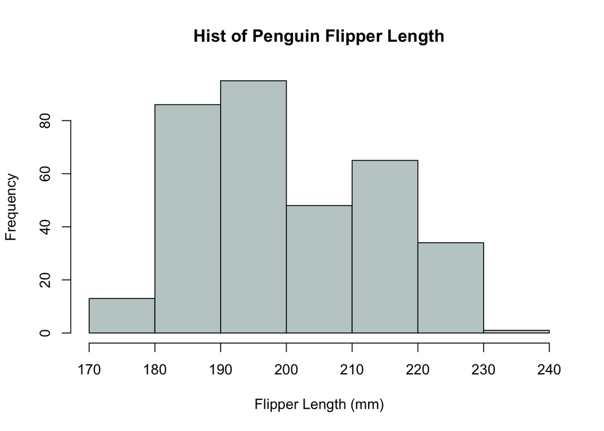

```r
hist(penguins$flipper_length_mm,
     main="Hist of Penguin Flipper Length",
     xlab="Flipper Length (mm)",
     col="azure3",
     breaks=6)
```

### Boxplots

Moving onto boxplots:

1. A classic boxplot

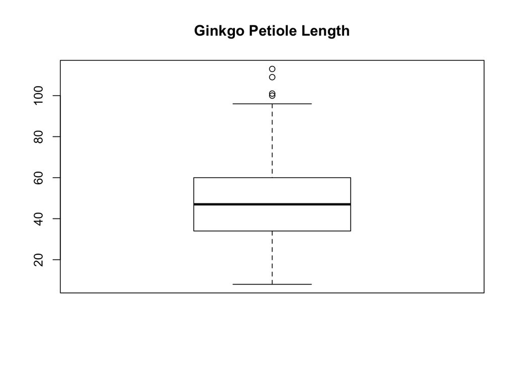

```r
boxplot(ginkgo$petiole_length,
        main="Ginkgo Petiole Length")
```

2. A conditional boxplot (conditioned on seeds_present)

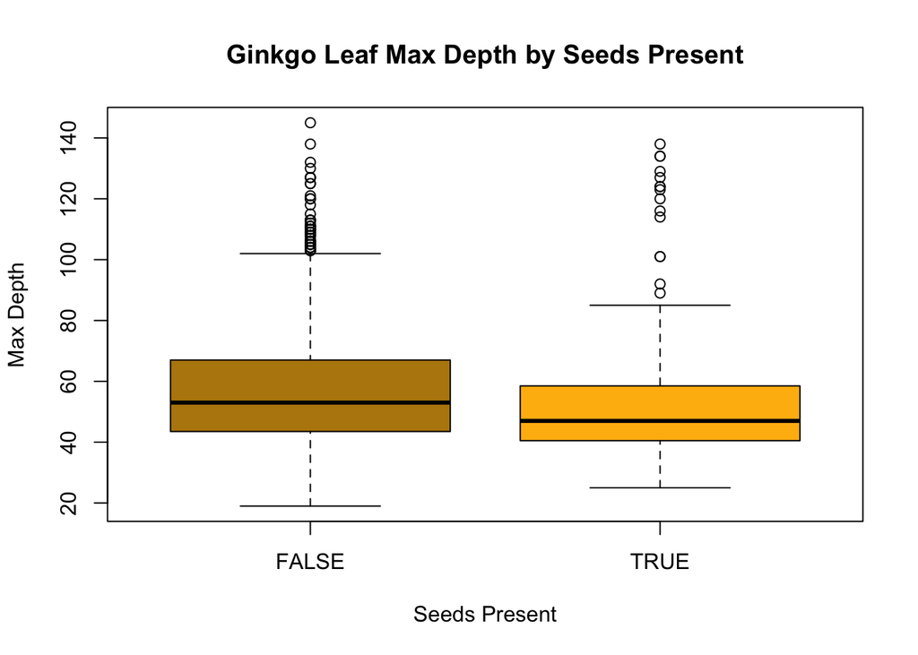

```r
boxplot(max_depth~seeds_present,data=ginkgo,
        main="Ginkgo Leaf Max Depth by Seeds Present",
        xlab="Seeds Present",
        ylab="Max Depth",
        col=c("darkgoldenrod","darkgoldenrod1"))
```

### Panels

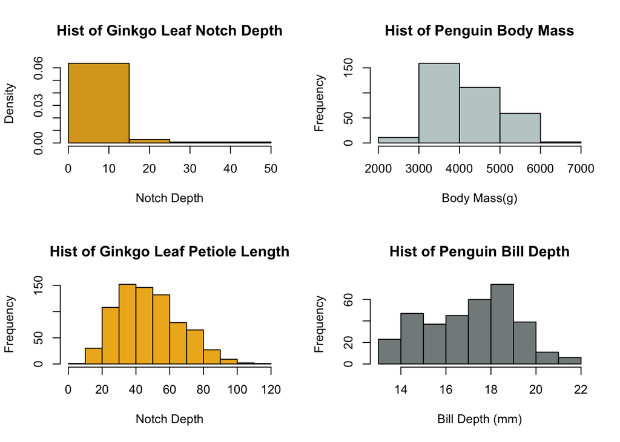

```r
par(mfrow=c(2,2))

hist(ginkgo$notch_depth,
     main="Hist of Ginkgo Leaf Notch Depth",
     xlab="Notch Depth",
     col="goldenrod",
     breaks=c(0,15,25,50))
hist(penguins$body_mass_g,
     main="Hist of Penguin Body Mass",
     xlab="Body Mass(g)",
     col="azure3",
     breaks=5)
hist(ginkgo$petiole_length,
     main="Hist of Ginkgo Leaf Petiole Length",
     xlab="Notch Depth",
     col="goldenrod2")
hist(penguins$bill_depth_mm,
     main="Hist of Penguin Bill Depth",
     xlab="Bill Depth (mm)",
     col="azure4",
     breaks=8)
```

## Distribution Functions

These functions calculate the probability of events for different parametric distributions.

For a discrete distribution (binomial), the probability mass of an event is the probability that the event will happen.

Each functions has a different argument, depending on the specific parameters of the distribution.

### dnorm( )

dnorm(x, mean = 0, sd = 1, log = FALSE): the probability density

```r
dnorm(-1, mean = 0, sd = 1, log = FALSE)
```

```
## [1] 0.2419707
```

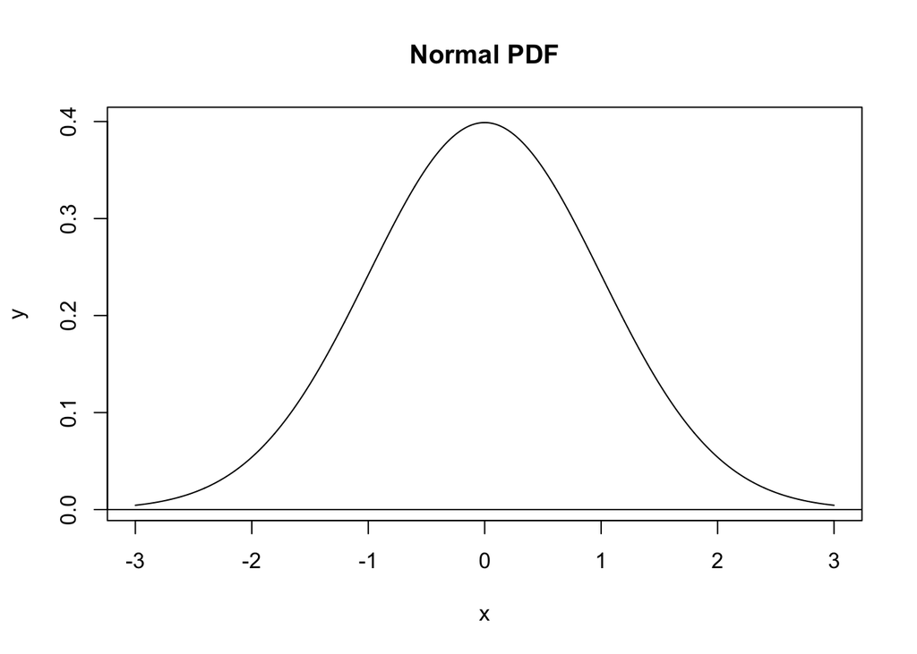

```r
#Basic plot of normal curve
# Generate a vector of x-values
x = seq(-3, 3, length.out = 1000)
y = dnorm(x)

plot(x, y, main = "Normal PDF", type = "l")
abline(h = 0)
```

### pnorm( )

pnorm(q, mean = 0, sd = 1, lower.tail = TRUE, log.p = FALSE): the cumulative probability density

```r
pnorm(-1.96, mean = 0, sd = 1, log = FALSE)
```

```
## [1] 0.0249979
```

```r
pnorm(20, mean=10.4, sd=2.4)
```

```
## [1] 0.9999683
```

### qnorm( )

qnorm(p, mean = 0, sd = 1, lower.tail = TRUE, log.p = FALSE): the quantile function

```r
#find the Z-score of the 99th quantile of the standard normal distribution
qnorm(.99, mean=0, sd=1)
```

```
## [1] 2.326348
```

### dbinom( )

```r
#Probabilty of observing four out of 6 with a 2/3 probabilty of observation
dbinom(4,6, 2/3)
```

```
## [1] 0.3292181
```

```r
#Probablity of observing 0
dbinom(0, 6, 2/3)
```

```
## [1] 0.001371742
```

### pbinom( )

The p-functions calculate the probability of observing a range of events (cumulative probability)

```r
#Probabilty of observing 4 or fewer out of 6 with a 2/3 probabilty of observation
pbinom(4, 6, 2/3)
```

```
## [1] 0.648834
```

```r
#4 or greater
1-pbinom(3, 6, 2/3)
```

```
## [1] 0.6803841
```

### qbinom( )

```r
#find the 10th quantile of a binomial distribution with 10 trials and prob of success on each trial = 0.4
qbinom(.10, 10, .4)
```

```
## [1] 2
```

That’s it for now!